# Pitcher card

# Jose Cuas

RHP · KC

2026 · 24 G (0 GS) · 473 pitches · Jul 01 – Sep 26, 2026

Independent portfolio sample by Devin Jenkinson, not affiliated with any club. Every number is computed from public Statcast data.

Three big takeaways

1Watch

The 4-seam fastball is his most-used two-strike pitch.

56% of two-strike pitches · 49 two-strike swings so far

No pitch has 50+ two-strike swings yet, so this card does not name a put-away pitch by miss rate.

2Avoid

Limit the 4-seam fastball. It is his most damaging pitch.

xRV/100 -0.44 shrunk (raw -1.02) · .411 xwOBAcon · 152 pitches

When behind in the count he throws it 23% of the time; the sinker grades +0.24 there instead.

3Watch

Build the sinker sample before setting a height plan.

18 swings up · 25 swings down

Rates under 50 swings are not quoted on this card.

Charts

### Movement

The ST finishes 23 in from his SI, with 23 in more glove-side run.

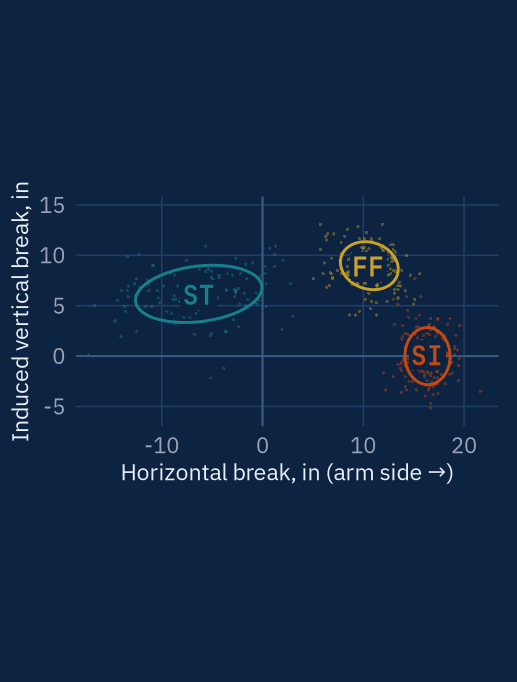

n = 448 pitches. Ellipses hold about 68% of each type; codes sit at the averages.

### Location by count

He throws 47% of pitches in the zone when behind and 36% when ahead.

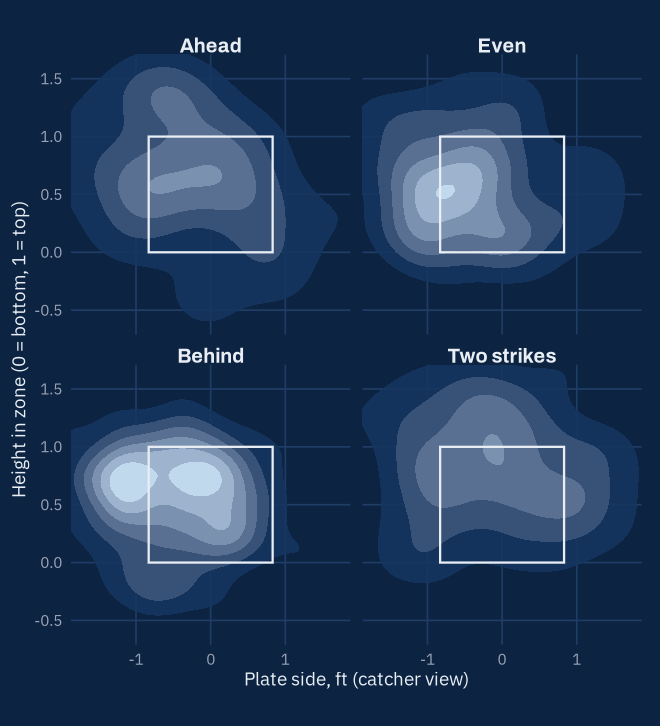

n = 448. Ahead 56 · even 139 · behind 106 · two strikes 147 pitches. Box = rule-book zone.

### Put-away

The FF is 56% of two-strike pitches vs 32% overall.

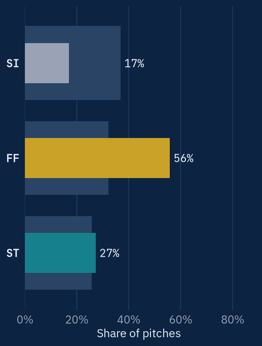

Two-strike n: FF 82, ST 40, SI 25. Grey bars = overall usage; wh = whiffs per swing (shown with 50+ swings).

### Arsenal

| Pitch | # | Use | Velo | IVB | HB | VAA | Whiff | Chase | xwOBAcon | xRV/100 | Stuff+ |
| --- | --- | --- | --- | --- | --- | --- | --- | --- | --- | --- | --- |
| Sinker (SI) | 174 | 37% | 92.0 | 0.1 | +16.3 | -4.9 | 18% | 36% | .363 | +0.24 | 101 |
| 4-Seam (FF) | 152 | 32% | 91.8 | 8.9 | +10.5 | -3.2 | 30% | 32% | .411 | -0.44 | 84 |
| Sweeper (ST) | 122 | 26% | 82.8 | 6.1 | -6.3 | -5.5 | 37% | 28% | .454 | +0.05 | 102 |

IVB / HB in inches (HB + = arm side). VAA in degrees at the front of the plate. xRV/100 = expected run value per 100 pitches, pitcher’s view, shrunk with a 250-pitch prior. Stuff+ = this project’s shape-only model (100 = MLB average, 10 = 1 SD).

### Vs. batter hand

| Pitch | LHH # | Use | Whiff | xwOBAcon | RHH # | Use | Whiff | xwOBAcon |
| --- | --- | --- | --- | --- | --- | --- | --- | --- |
| SI | 59 | 28% | – | .496 | 115 | 49% | 18% | .286 |
| FF | 99 | 46% | – | .353 | 53 | 23% | – | .325 |
| ST | 55 | 26% | – | .281 | 67 | 29% | – | .322 |

Use = share of pitches to that side. Whiff = whiffs per swing, shown with 50+ swings.